# 431 Class 07

Thomas E. Love, Ph.D.

2026-09-15

## Today’s Agenda

- What does “Normalish” data look like?
- Comparing Two Samples
  - Paired vs. Independent Samples
  - Checking Assumptions
  - How should we interpret an uncertainty interval?
- Transforming an Outcome (see [Chapter 7](https://thomaselove.github.io/431-book/))
  - The importance of power transformations
  - Tukey’s ladder and the Box-Cox plot

## Load packages and set theme

```r
knitr::opts_chunk$set(comment = NA)
source("c07/data/Love-431.R") # for the lovedist() function

library(janitor)
library(patchwork)
library(readxl)
library(knitr)
library(kableExtra)
library(MKinfer)
library(rstanarm)
library(car)
library(easystats)
library(tidyverse)

theme_set(theme_bw())
```

## A Simulated Data Set

```r
dat07
```

```
# A tibble: 125 × 6
    var1  var2  var3  var4  var5  var6
   <dbl> <dbl> <dbl> <dbl> <dbl> <dbl>
 1 114.  132.   92.0 114.  113.   97.1
 2 117.  102.  119.   99.6 113.  124.
 3 109.   78.1  89.4 115.   83.7 122.
 4  99.6  99.3  92.3  89.4 107.  105.
 5  95.8 121.   93.3 111.  104.  115.
 6  79.4  99.8 102.   92.2 115.  113.
 7  87.7  90.4  80.7  89.6  95.3 113.
 8  86.1 144.   99.9  86.9  58.0 110.
 9 116.   56.4  78.3 117.  115.   93.7
10  95.5  94.3 103.   86.3  99.6  92.1
# ℹ 115 more rows
```

Simulation details for `dat07` tibble are in the Quarto code.

## Numerical Summaries

```r
res1 <- dat07 |> reframe(lovedist(var1)) |> mutate(variable = "var1")
res2 <- dat07 |> reframe(lovedist(var2)) |> mutate(variable = "var2")
res3 <- dat07 |> reframe(lovedist(var3)) |> mutate(variable = "var3")
res4 <- dat07 |> reframe(lovedist(var4)) |> mutate(variable = "var4")
res5 <- dat07 |> reframe(lovedist(var5)) |> mutate(variable = "var5")
res6 <- dat07 |> reframe(lovedist(var6)) |> mutate(variable = "var6")

rbind(res1, res2, res3, res4, res5, res6) |> relocate(variable) |>
  kable(digits = c(0, 0, 0, 2, 2, 2, 2, 1, 1, 1, 1)) |>
  kable_styling(font_size = 24)
```

| variable | n | miss | mean | sd | med | mad | min | q25 | q75 | max |
| --- | --- | --- | --- | --- | --- | --- | --- | --- | --- | --- |
| var1 | 125 | 0 | 102.37 | 16.12 | 100.61 | 17.40 | 54.4 | 89.7 | 115.2 | 149.3 |
| var2 | 125 | 0 | 101.20 | 14.24 | 100.09 | 8.56 | 56.4 | 95.8 | 107.4 | 143.5 |
| var3 | 125 | 0 | 101.78 | 19.63 | 96.35 | 14.87 | 75.7 | 89.3 | 112.0 | 178.8 |
| var4 | 125 | 0 | 102.19 | 11.04 | 101.68 | 13.26 | 83.7 | 93.7 | 111.5 | 122.9 |
| var5 | 125 | 0 | 101.25 | 13.29 | 103.93 | 12.57 | 56.9 | 95.5 | 112.2 | 117.0 |
| var6 | 125 | 0 | 102.79 | 16.13 | 102.16 | 16.25 | 60.2 | 93.7 | 114.2 | 143.9 |

## Histograms of `dat07` variables

```r
H1 <- ggplot(dat07, aes(x = var1)) + labs(title = "Histogram of var1") +
  geom_histogram(binwidth = 6, col = "black", fill = "skyblue")
H2 <- ggplot(dat07, aes(x = var2)) + labs(title = "Histogram of var2") +
  geom_histogram(binwidth = 6, col = "black", fill = "plum")
H3 <- ggplot(dat07, aes(x = var3)) + labs(title = "Histogram of var3") +
  geom_histogram(binwidth = 6, col = "black", fill = "coral")
H4 <- ggplot(dat07, aes(x = var4)) + labs(title = "Histogram of var4") +
  geom_histogram(binwidth = 3, col = "black", fill = "aquamarine")
H5 <- ggplot(dat07, aes(x = var5)) + labs(title = "Histogram of var5") +
  geom_histogram(binwidth = 4, col = "black", fill = "slateblue")
H6 <- ggplot(dat07, aes(x = var6)) + labs(title = "Histogram of var6") +
  geom_histogram(binwidth = 6, col = "black", fill = "burlywood")

(H1 + H2 + H3) / (H4 + H5 + H6)
```

## Histograms of `dat07` variables

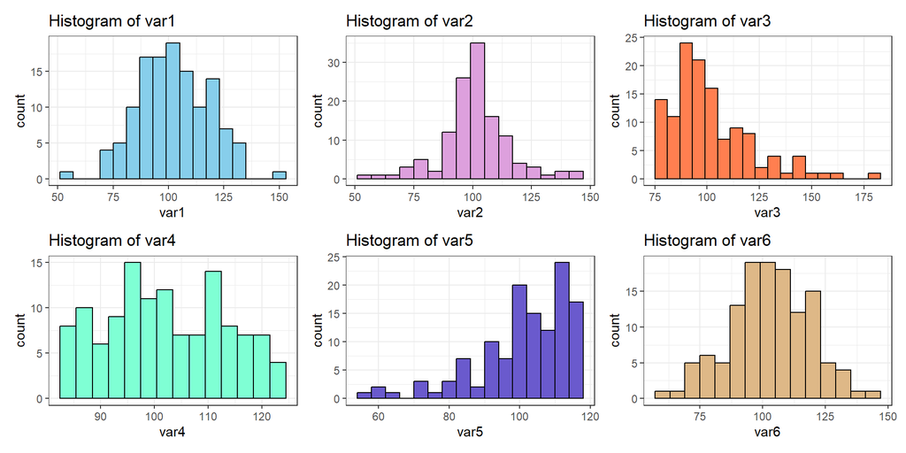

## Three-Plot Summary for `var01`

```r
plot1A <- ggplot(dat07, aes(sample = var1)) +
  geom_qq(shape = 21, fill = "skyblue") + geom_qq_line(col = "red") +
  labs(title = "Normal Q-Q plot of var1", y = "var1", x = "Standard Normal")
plot1B <- ggplot(dat07, aes(x = var1)) +
  geom_histogram(binwidth = 6, col = "black", fill = "skyblue") +
  stat_function(fun = function(x)
    dnorm(x, mean = mean(dat07$var1, na.rm = TRUE),
          sd = sd(dat07$var1,na.rm = TRUE)) *
      length(dat07$var1) * 6,
    geom = "area", alpha = 0.5, fill = "linen", col = "black") +
  labs(title = "Histogram of var1", y = "")
plot1C <- ggplot(dat07, aes(x = var1, y = "")) +
  geom_violin(fill = "skyblue") + geom_boxplot(width = 0.3) +
  stat_summary(fun = "mean", geom = "point", col = "red") +
  labs(title = "Boxplot of var1", y = "", x = "var1")

plot1A + (plot1B / plot1C + plot_layout(heights = c(2,1)))
```

## Three-Plot Summary for `var01`

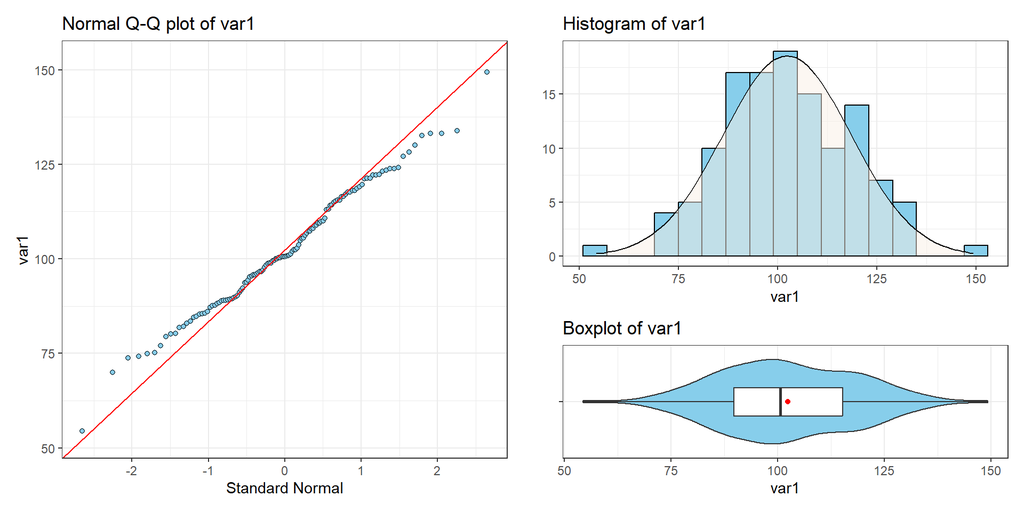

## Three-Plot Summary for `var02`

```r
plot2A <- ggplot(dat07, aes(sample = var2)) +
  geom_qq(shape = 21, fill = "plum") + geom_qq_line(col = "red") +
  labs(title = "Normal Q-Q plot of var2", y = "var2", x = "Standard Normal")
plot2B <- ggplot(dat07, aes(x = var2)) +
  geom_histogram(binwidth = 6, col = "black", fill = "plum") +
  stat_function(fun = function(x)
    dnorm(x, mean = mean(dat07$var2, na.rm = TRUE),
          sd = sd(dat07$var2,na.rm = TRUE)) *
      length(dat07$var2) * 6,
    geom = "area", alpha = 0.5, fill = "linen", col = "black") +
  labs(title = "Histogram of var2", y = "")
plot2C <- ggplot(dat07, aes(x = var2, y = "")) +
  geom_violin(fill = "plum") + geom_boxplot(width = 0.3) +
  stat_summary(fun = "mean", geom = "point", col = "red") +
  labs(title = "Boxplot of var2", y = "", x = "var2")

plot2A + (plot2B / plot2C + plot_layout(heights = c(2,1)))
```

## Three-Plot Summary for `var02`

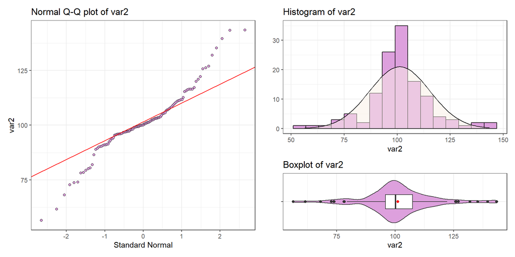

## Three-Plot Summary for `var03`

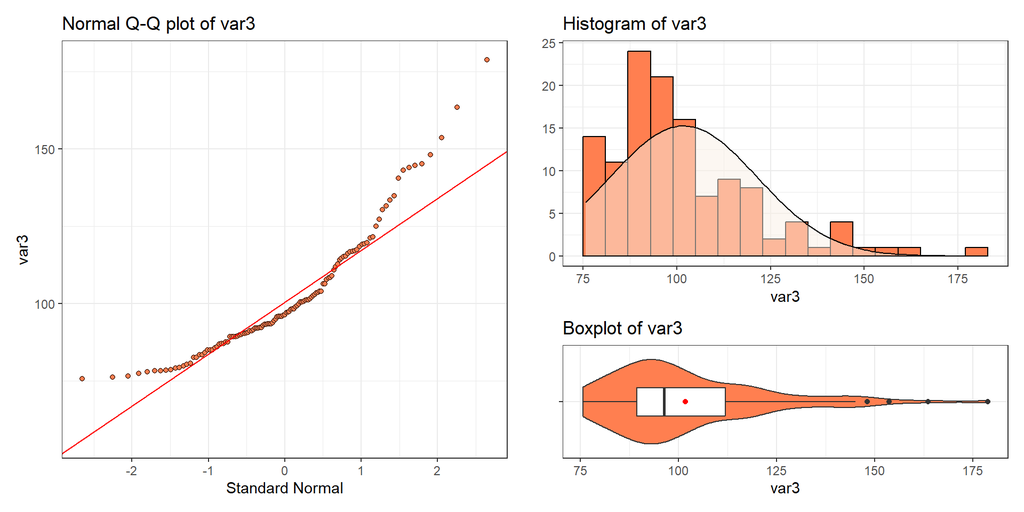

## Three-Plot Summary for `var04`

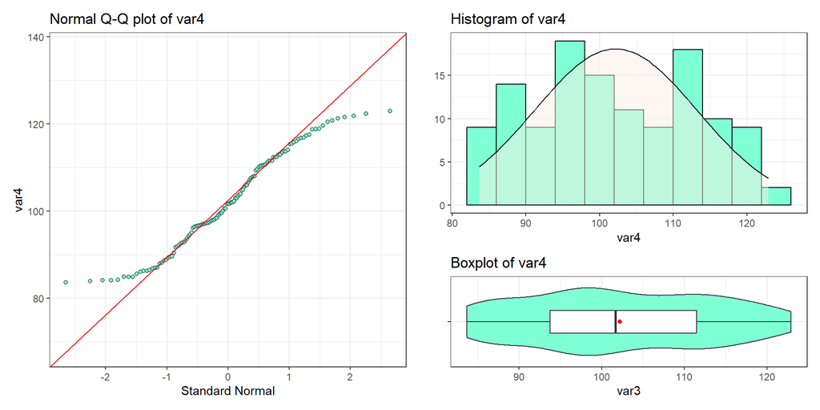

## Three-Plot Summary for `var05`

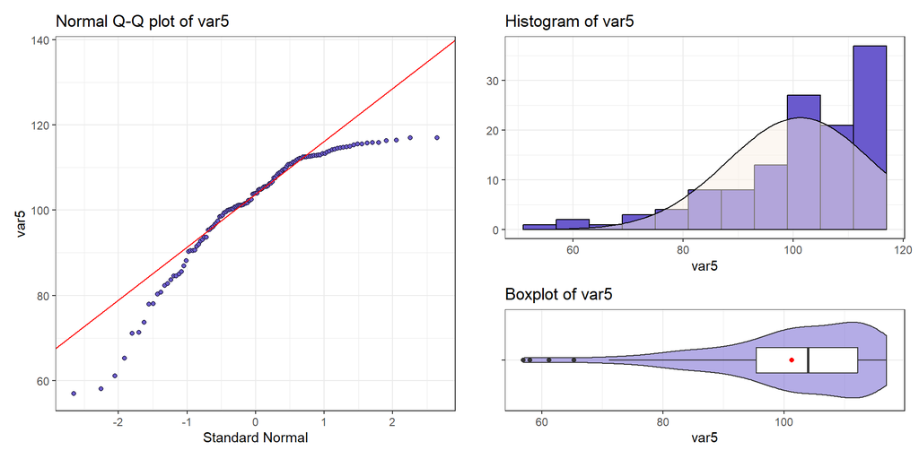

## Three-Plot Summary for `var06`

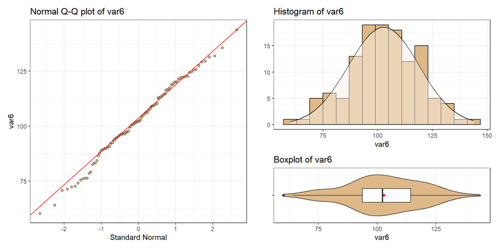

## New Data: Ohio’s 88 Counties

Adult obesity rates (% of adult county residents reporting body-mass index of 30 $kg/m^2$ or higher) from County Health Rankings Reports in 2014 and 2024.

- CHR 2024 reports **2021** data from the Behavioral Risk Factor Surveillance System.
- CHR 2014 reports **2010** data from the National Center for Chronic Disease Prevention and Health Promotion, Division of Diabetes Translation.

## Obesity in Ohio Counties

```r
ohio88 <- read_csv("c07/data/ohio88.csv", show_col_types = FALSE) |>
  janitor::clean_names() |>
  mutate(obesity_diff = obesity_2024 - obesity_2014) |>
  select(county, obesity_2024, obesity_2014, obesity_diff)

ohio88 |> filter(county %in%
                  c("Cuyahoga", "Geauga", "Lake", "Lorain",
                    "Medina", "Portage", "Summit"))
```

```
# A tibble: 7 × 4
  county   obesity_2024 obesity_2014 obesity_diff
  <chr>           <dbl>        <dbl>        <dbl>
1 Cuyahoga           35           27            8
2 Geauga             35           28            7
3 Lake               37           28            9
4 Lorain             37           31            6
5 Medina             38           29            9
6 Portage            35           30            5
7 Summit             43           29           14
```

## Our Question

What can we say about the mean of the difference between the county-level obesity rates reported in 2024 and those reported in 2014?

- What is the outcome of interest?
- What two groups are we comparing?
- Do we have paired or independent samples here?

## Numerical Summaries

```r
res1 <- ohio88 |> reframe(lovedist(obesity_2024)) |> mutate(var = "2024")
res2 <- ohio88 |> reframe(lovedist(obesity_2014)) |> mutate(var = "2014")
res3 <- ohio88 |> reframe(lovedist(obesity_diff)) |> mutate(var = "diffs")

rbind(res1, res2, res3) |> relocate(var) |>
  kable(digits = c(0, 0, 0, 2, 2, 2, 2, 1, 1, 1, 1)) |>
  kable_styling(font_size = 28)
```

| var | n | miss | mean | sd | med | mad | min | q25 | q75 | max |
| --- | --- | --- | --- | --- | --- | --- | --- | --- | --- | --- |
| 2024 | 88 | 0 | 40.69 | 3.12 | 41 | 2.97 | 34 | 38.8 | 43.0 | 47 |
| 2014 | 88 | 0 | 31.30 | 2.45 | 31 | 1.48 | 26 | 30.0 | 33.0 | 37 |
| diffs | 88 | 0 | 9.40 | 2.94 | 9 | 2.97 | 2 | 8.0 | 11.2 | 15 |

## Plotting Paired Differences

```r
p1 <- ggplot(ohio88, aes(sample = obesity_diff)) +
  geom_qq() +
  geom_qq_line(col = "red") +
  labs(y = "2024 - 2014 difference",
       x = "Standard Normal Distribution",
    title = "Changes in Adult Obesity, 2024-2014")

bw <- 1 # specify width of bins in histogram

p2 <- ggplot(ohio88, aes(obesity_diff)) +
  geom_histogram(binwidth = bw, fill = "black", col = "yellow" ) +
  stat_function(fun = function(x) {
    dnorm(x, mean = mean(ohio88$obesity_diff, na.rm = TRUE),
          sd = sd(ohio88$obesity_diff, na.rm = TRUE) ) *
        length(ohio88$obesity_diff) * bw},
    geom = "area", alpha = 0.5, fill = "lightblue", col = "blue") +
  labs(x = "2024 - 2014 difference", y = "",
       title = "Histogram of 88 Ohio Counties")

p3 <- ggplot(ohio88, aes(x = obesity_diff, y = "")) +
  geom_violin(fill = "cornsilk") +
  geom_boxplot(width = 0.2) +
  stat_summary(fun = mean, geom = "point", shape = 16, col = "red") +
  labs(y = "", x = "2024 - 2014 difference",
       title = "Boxplot with Violin: 88 Ohio Counties")

p1 + (p2 / p3 + plot_layout(heights = c(2, 1))) +
  plot_annotation(title = "2024 - 2014 Difference in CHR Adult Obesity Rates")
```

## Plotting Paired Differences

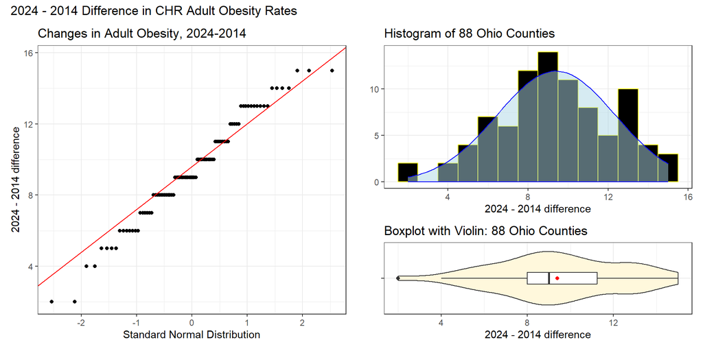

## Our paired differences

```r
ohio88 |> tabyl(obesity_diff) |> adorn_pct_formatting()
```

```
 obesity_diff  n percent
            2  2    2.3%
            4  2    2.3%
            5  4    4.5%
            6  7    8.0%
            7  6    6.8%
            8 12   13.6%
            9 14   15.9%
           10 11   12.5%
           11  8    9.1%
           12  5    5.7%
           13 10   11.4%
           14  4    4.5%
           15  3    3.4%
```

## Our 88 Paired Differences

```r
ohio88 |> reframe(lovedist(obesity_diff))
```

```
# A tibble: 1 × 10
      n  miss  mean    sd   med   mad   min   q25   q75   max
  <int> <int> <dbl> <dbl> <dbl> <dbl> <dbl> <dbl> <dbl> <dbl>
1    88     0  9.40  2.94     9  2.97     2     8  11.2    15
```

What can we say about the distribution of paired differences in our sample?

- Do we see meaningful skew?
- Do we see meaningfully heavy or light tails?
- Which comparison approach should we use?

## OLS/t-based approach

```r
m2a <- lm(obesity_diff ~ 1, data = ohio88)

model_parameters(m2a, conf.level = 0.95)
```

```
Parameter   | Coefficient |   SE |        95% CI | t(87) |      p
-----------------------------------------------------------------
(Intercept) |        9.40 | 0.31 | [8.77, 10.02] | 29.96 | < .001
```

```r
m2b <- t.test(ohio88$obesity_diff, conf.level = 0.95)
model_parameters(m2b)
```

```
One Sample t-test

Parameter    | Mean | mu | Difference |        95% CI | t(87) |      p
----------------------------------------------------------------------
obesity_diff | 9.40 |  0 |       9.40 | [8.77, 10.02] | 29.96 | < .001

Alternative hypothesis: true mean is not equal to 0
```

## Bayesian Linear Model

```r
set.seed(43101)
m3 <- stan_glm(obesity_diff ~ 1, data = ohio88, refresh = 0)
model_parameters(m3, conf.level = 0.95)
```

```
Parameter   | Median |        95% CI |   pd |  Rhat | ESS (tail) |                 Prior
----------------------------------------------------------------------------------------
(Intercept) |   9.39 | [8.77, 10.03] | 100% | 1.000 |       2405 | Normal (9.40 +- 7.36)
```

## Bootstrap approach

```r
set.seed(432071)
boot.t.test(ohio88$obesity_diff, R = 2000, conf.level = 0.95)
```

```
    Bootstrap One Sample t-test

data:  ohio88$obesity_diff
number of bootstrap samples:  2000
bootstrap p-value < 5e-04
bootstrap mean of x (SE) = 9.401795 (0.3100755)
95 percent bootstrap percentile confidence interval:
 8.783807 9.988636

Results without bootstrap:
t = 29.964, df = 87, p-value < 2.2e-16
alternative hypothesis: true mean is not equal to 0
95 percent confidence interval:
  8.774351 10.021104
sample estimates:
mean of x
 9.397727
```

## Our estimates

| Approach | Estimate | 95% confidence interval |
| --- | --- | --- |
| OLS / t | 9.40 | (8.77, 10.02) |
| Bayes | 9.39 | (8.77, 10.03) |
| Bootstrap | 9.40 | (8.78, 9.99) |

- Which of these should we choose?
  - Or does it not matter much?
- Once we’ve made a choice, how can we describe the result properly?

## Choosing OLS for Paired t

*Paired t result: Estimate = 9.40, 95% CI (8.77, 10.02)*

- Our best point estimate for the true difference (2024-2014 reports on adult obesity) is 9.40 percentage points, based on our sample of 88 Ohio counties.
- The confidence interval reflects imprecision in the population estimate, based on assuming that the counties in our sample are selected at random from the population of interest, and that the assumptions of our paired t procedure hold.

## Interpreting the Confidence Interval

*Paired t result: Estimate = 9.40, 95% CI (8.77, 10.02)*

When we generalize beyond these counties to the population they were **selected at random** from, then our data are **compatible** (at the 95% confidence level) with population mean differences in adult obesity rates between 8.77 and 10.02 percentage points, depending on the **assumptions of our linear model** (paired t test) being correct.

## Paired Samples Strategy (1)

Suppose we want to estimate an uncertainty interval for the mean of a set of paired differences.

- Calculate the paired differences, then plot them.
- If the sample data are well described as “Normal”, then use the OLS / paired t procedure to obtain a confidence interval, or a Bayesian model to obtain a credible interval.

## Paired Samples Strategy (2)

- If the sample data are best described as “symmetric but with outliers”, then use the bootstrap to obtain a confidence interval, although an OLS or Bayesian result may be quite similar.
- If the sample data are best described as “substantially skewed”, then consider whether you actually want to summarize with the mean, and consider whether a transformation might be helpful.

# Standing Break

## New Data: `dm464` from Classes 5-6

```r
dm464 <- read_xlsx("c07/data/dm464.xlsx") |>
  janitor::clean_names() |>
  select(id_code, ldl = ldl_start, statin = statin_start) |>
  mutate(across(where(is.character), as_factor)) |>
  mutate(id_code = as.character(id_code)) |>
  mutate(stat_f = fct_recode(factor(statin), "Statin" = "1", "No" = "0"))

head(dm464)
```

```
# A tibble: 6 × 4
  id_code   ldl statin stat_f
  <chr>   <dbl>  <dbl> <fct>
1 DM-1007   203      1 Statin
2 DM-1017    88      1 Statin
3 DM-1039   139      1 Statin
4 DM-1049   188      1 Statin
5 DM-1064   112      0 No
6 DM-1070    81      1 Statin
```

## What is our goal?

Goal: 90% uncertainty interval for difference in average LDL between Statin and No Statin groups.

```r
dm464 |> group_by(stat_f) |> reframe(lovedist(ldl)) |>
  kable(digits = c(0, 0, 0, 2, 2, 2, 2, 0, 0, 0, 0)) |>
  kable_styling(font_size = 24)
```

| stat_f | n | miss | mean | sd | med | mad | min | q25 | q75 | max |
| --- | --- | --- | --- | --- | --- | --- | --- | --- | --- | --- |
| No | 97 | 0 | 96.26 | 31.63 | 91 | 28.17 | 40 | 75 | 112 | 225 |
| Statin | 367 | 0 | 103.43 | 39.51 | 93 | 34.10 | 40 | 77 | 126 | 231 |

- What are we comparing? What is our outcome? How many group means?
- Are these paired or independent samples?

## Estimate 1: Pooled t procedure

Pooled t procedure using `lm` (ordinary least squares)

```r
fit1 <- lm(ldl ~ stat_f, data = dm464)
model_parameters(fit1, ci = 0.90) |>
  kable(digits = 2) |> kable_styling(font_size = 24)
```

| Parameter | Coefficient | SE | CI | CI_low | CI_high | t | df_error | p |
| --- | --- | --- | --- | --- | --- | --- | --- | --- |
| (Intercept) | 96.26 | 3.86 | 0.9 | 89.90 | 102.62 | 24.94 | 462 | 0.0 |
| stat_fStatin | 7.17 | 4.34 | 0.9 | 0.02 | 14.32 | 1.65 | 462 | 0.1 |

### Assumptions for Pooled t procedure

1. Random sample from statin and no statin populations
2. Each sample comes from a Normal population
3. Equal population variances in the two statin groups

## Interpreting the Pooled t result (1/2)

*Pooled t result: Estimate = 7.17, 90% CI (0.02, 14.32)*

- Our best point estimate for the true difference (Statin - No Statin) is 7.17 mg/dl in LDL cholesterol at baseline, based on our sample of 367 Statin and 97 No statin subjects with diabetes.
- The confidence interval reflects imprecision in the population estimate, based on assuming that the people in our sample are selected at random from the population of interest, *and* that the assumptions of our pooled t procedure hold.

## Interpreting the Pooled t result (2/2)

When we generalize beyond these 464 subjects with diabetes to the population they were **selected at random** from, then our data are **compatible** (at the 90% confidence level) with population mean differences in LDL between 0.02 and 14.32 mg/dl, depending on the **assumptions of our linear model** (pooled t test) being correct.

## Estimate 2: Bayesian linear model

If we use the default (weakly informative) prior, then the Bayesian model has essentially the same assumptions as the pooled t procedure:

```r
set.seed(4312)
fit2 <- stan_glm(ldl ~ stat_f, data = dm464, refresh = 0)
model_parameters(fit2, ci = 0.90) |>
  kable(digits = 2) |> kable_styling(font_size = 24)
```

| Parameter | Median | CI | CI_low | CI_high | pd | Rhat | ESS_tail | Prior_Distribution | Prior_Location | Prior_Scale |
| --- | --- | --- | --- | --- | --- | --- | --- | --- | --- | --- |
| (Intercept) | 96.21 | 0.9 | 89.91 | 102.71 | 1.00 | 1 | 2515 | normal | 101.93 | 95.20 |
| stat_fStatin | 7.16 | 0.9 | 0.17 | 14.65 | 0.95 | 1 | 2599 | normal | 0.00 | 233.87 |

## Estimate 3: Welch’s t procedure

Welch’s t procedure drops requirement of equal population variances

```r
fit3 <- t.test(ldl ~ stat_f, data = dm464)
model_parameters(fit3, ci = 0.90)
```

```
Welch Two Sample t-test

Parameter |  Group | stat_f = No | stat_f = Statin | Difference
---------------------------------------------------------------
ldl       | stat_f |       96.26 |          103.43 |      -7.17

Parameter |         90% CI | t(183.36) |     p
----------------------------------------------
ldl       | [-14.70, 0.36] |     -1.88 | 0.062

Alternative hypothesis: true difference in means between group No and group Statin is not equal to 0
```

## Estimate 4: Bootstrap with pooling

Bootstrap (percentile) procedure (with pooling) maintains assumption of equal population variances but does not require Normally distributed populations

```r
set.seed(43104)
boot.t.test(ldl ~ stat_f, var.equal = TRUE, R = 2000,
  data = dm464, conf.level = 0.90)
```

```
    Bootstrap Two Sample t-test

data:  ldl by stat_f
number of bootstrap samples:  2000
bootstrap p-value = 0.093
bootstrap difference of means (SE) = -7.251915 (4.34287)
90 percent bootstrap percentile confidence interval:
 -14.2840024  -0.1761131

Results without bootstrap:
t = -1.6523, df = 462, p-value = 0.09915
alternative hypothesis: true difference in means is not equal to 0
90 percent confidence interval:
 -14.32216921  -0.01795271
sample estimates:
    mean in group No mean in group Statin
            96.25773            103.42779
```

## Estimate 5: Bootstrap: unpooled

Bootstrap (percentile) procedure (without pooling) drops assumptions of equal population variances and of Normally distributed populations

```r
set.seed(43105)
boot.t.test(ldl ~ stat_f, var.equal = FALSE, R = 2000,
  data = dm464, conf.level = 0.90)
```

```
    Bootstrap Welch Two Sample t-test

data:  ldl by stat_f
number of bootstrap samples:  2000
bootstrap p-value = 0.056
bootstrap difference of means (SE) = -7.0623 (3.784715)
90 percent bootstrap percentile confidence interval:
 -12.9985828  -0.8738097

Results without bootstrap:
t = -1.8786, df = 183.36, p-value = 0.06188
alternative hypothesis: true difference in means is not equal to 0
90 percent confidence interval:
 -13.4797701  -0.8603518
sample estimates:
    mean in group No mean in group Statin
            96.25773            103.42779
```

## Results So Far

- All methods assume random samples
- Est. = point estimate of Statin - No Statin group mean difference

| Method | Est. | 90% Interval | Assumptions |
| --- | --- | --- | --- |
| Pooled t | 7.17 | (0.02, 14.32) | Normality, equal variances |
| Bayesian | 7.16 | (0.17, 14.65) | Same as pooled t, basically |
| Welch t | 7.17 | (-0.36, 14.70) | Normality only |
| Boot (pooled) | 7.25 | (0.18, 14.28) | Equal variances only |
| Boot (Welch) | 7.06 | (0.87, 12.99) | Neither |

- So what do we need to look for in our data?

## LDL by Statin prescription status

Comparison Boxplot with Violins

```r
ggplot(dm464, aes(x = ldl, y = stat_f)) +
  geom_violin() +
  geom_boxplot(aes(fill = stat_f), width = 0.3) +
  stat_summary(fun = mean, geom = "point",
               shape = 18, size = 4, col = "black") +
  guides(fill = "none") +
  labs(y = "Statin prescription", x = "LDL Cholesterol (mg/dl)",
       title = "LDL by Statin prescription")
```

## LDL by Statin prescription status

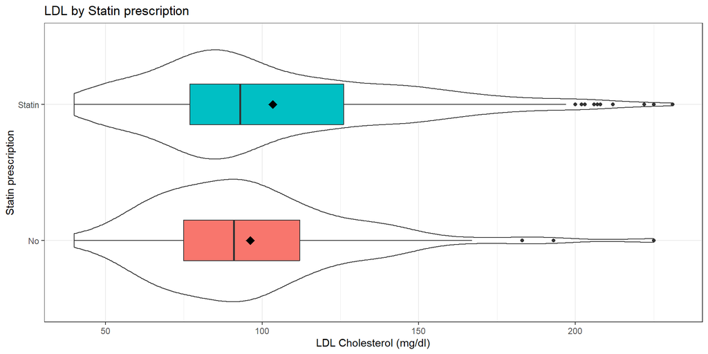

## LDL by Statin prescription status

How about a pair of Normal Q-Q plots?

```r
p1 <- dm464 |>
  filter(stat_f == "Statin") |>
  ggplot(aes(sample = ldl)) +
  geom_qq() + geom_qq_line(col = "red") +
  labs(title = "Statin group", y = "LDL Cholesterol (mg/dl)",
        x = "Standard Normal")

p2 <- dm464 |>
  filter(stat_f == "No") |>
  ggplot(aes(sample = ldl)) +
  geom_qq() + geom_qq_line(col = "red") +
  labs(title = "No Statin group", y = "LDL Cholesterol (mg/dl)",
        x = "Standard Normal")

p1 + p2 +
  plot_annotation(title = "Normal Q-Q plots of LDL by Statin group")
```

## LDL by Statin prescription status

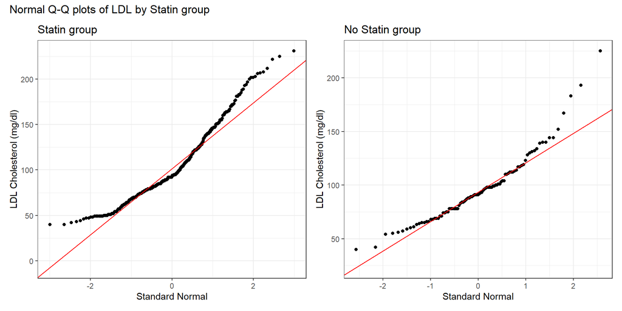

## LDL by Statin prescription status

A look at some numerical summaries…

```r
dm464 |> group_by(stat_f) |> reframe(lovedist(ldl)) |>
  kable(digits = 2) |> kable_styling(font_size = 28)
```

| stat_f | n | miss | mean | sd | med | mad | min | q25 | q75 | max |
| --- | --- | --- | --- | --- | --- | --- | --- | --- | --- | --- |
| No | 97 | 0 | 96.26 | 31.63 | 91 | 28.17 | 40 | 75 | 112 | 225 |
| Statin | 367 | 0 | 103.43 | 39.51 | 93 | 34.10 | 40 | 77 | 126 | 231 |

- skew<sub>1</sub> for “Statin” = (103.43 - 93)/39.51 = 0.26
- skew<sub>1</sub> for “No” = (96.26 - 91)/31.63 = 0.17

Our rough cutoff for substantial right skew ~ 0.20.

## What can we do about the skew?

- Could we build a confidence interval for medians instead of means?
  - Yes, with the bootstrap, for example see [Section 6.9.2](https://thomaselove.github.io/431-book/06_twogroups.html#bootstrap-ci-for-medians) of my text.
- Could we transform the data in a non-linear way to better match assumptions?
  - Yes, with the help of **Tukey’s ladder** of power transformations.

## Tukey’s Ladder

| Power ($\lambda$) | -2 | -1 | -0.5 | 0 | 0.5 | *1* | 2 | 3 |
| --- | --- | --- | --- | --- | --- | --- | --- | --- |
| Transform | $\frac{1}{y^2}$ | $\frac{1}{y}$ | $\frac{1}{\sqrt{y}}$ | $\log{y}$ | $\sqrt{y}$ | *y* | $y^2$ | $y^3$ |

- Start at no transformation ($\lambda$ = 1)
  - Try moving in one direction, searching for a better result (more “Normal” distribution)
  - Keep going until you start turning in the wrong direction.

## Tukey’s Ladder

| Power ($\lambda$) | -2 | -1 | -0.5 | 0 | 0.5 | 1 | 2 | 3 |
| --- | --- | --- | --- | --- | --- | --- | --- | --- |
| Transform | $\frac{1}{y^2}$ | $\frac{1}{y}$ | $\frac{1}{\sqrt{y}}$ | $\log{y}$ | $\sqrt{y}$ | $y$ | $y^2$ | $y^3$ |

- These power transformations help us address skew, mainly.
- They’re not much help if the data are symmetric, but have heavy/light tails.
- Some transformations require all values to be positive. If they aren’t, we can add a small amount to each observation until they are.

## LDL (untransformed) by statin

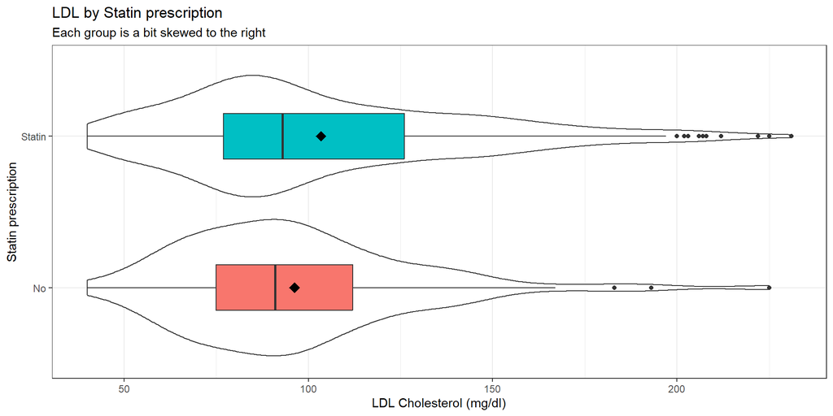

- Let’s try $\lambda = 2$, **squaring** the LDL values.

## LDL squared, by statin

```r
ggplot(dm464, aes(x = ldl^2, y = stat_f)) +
  geom_violin() +
  geom_boxplot(aes(fill = stat_f), width = 0.3) +
  stat_summary(fun = mean, geom = "point",
               shape = 18, size = 4, col = "black") +
  guides(fill = "none") +
  labs(y = "Statin prescription", x = "LDL^2",
       title = "LDL^2 by Statin prescription")
```

- Is this an improvement?

## LDL squared, by statin

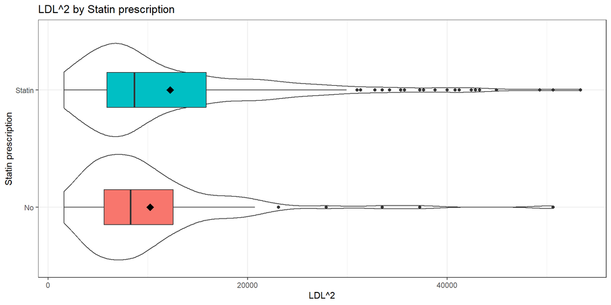

## Square root of LDL?

```r
ggplot(dm464, aes(x = sqrt(ldl), y = stat_f)) +
  geom_violin() +
  geom_boxplot(aes(fill = stat_f), width = 0.3) +
  stat_summary(fun = mean, geom = "point",
               shape = 18, size = 4, col = "black") +
  guides(fill = "none") +
  labs(y = "Statin prescription", x = "sqrt(LDL)",
       title = "Square Root of LDL by Statin prescription")
```

## Square root of LDL?

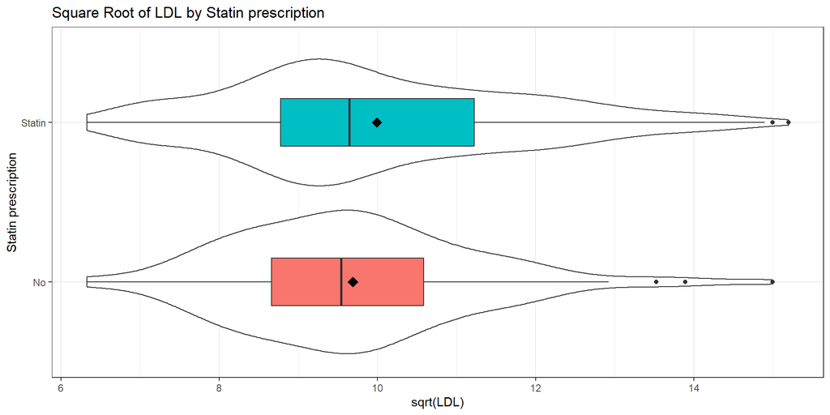

## Logarithm of LDL?

```r
ggplot(dm464, aes(x = log(ldl), y = stat_f)) +
  geom_violin() +
  geom_boxplot(aes(fill = stat_f), width = 0.3) +
  stat_summary(fun = mean, geom = "point",
               shape = 18, size = 4, col = "black") +
  guides(fill = "none") +
  labs(y = "Statin prescription", x = "log(LDL)",
       title = "Logarithm of LDL by Statin prescription")
```

## Logarithm of LDL?

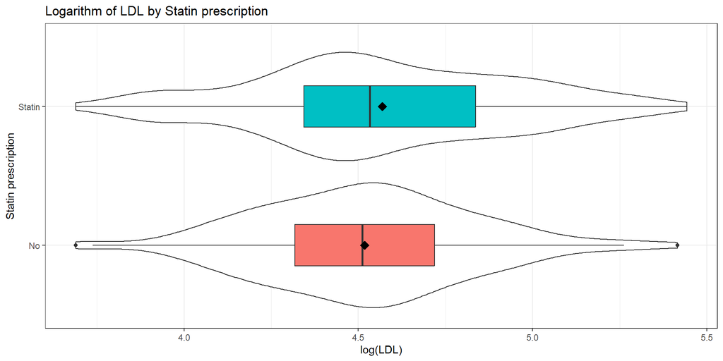

## Inverse of LDL?

```r
ggplot(dm464, aes(x = (1/ldl), y = stat_f)) +
  geom_violin() +
  geom_boxplot(aes(fill = stat_f), width = 0.3) +
  stat_summary(fun = mean, geom = "point",
               shape = 18, size = 4, col = "black") +
  guides(fill = "none") +
  labs(y = "Statin prescription", x = "1/LDL",
       title = "Inverse of LDL by Statin prescription")
```

## Inverse of LDL?

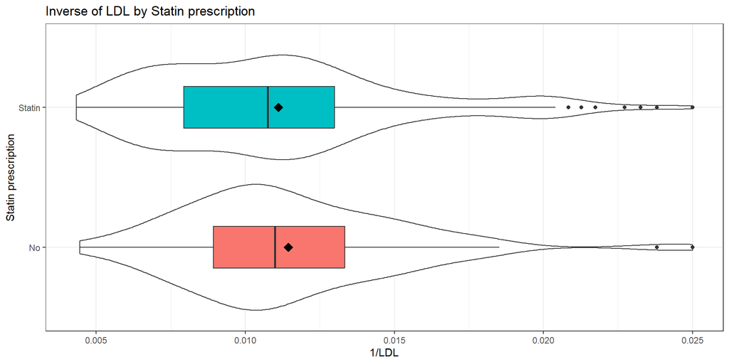

## Which Transformation to Choose?

Box-Cox approach: can we get a suggested “power” to use when transforming our outcome?

- Specify the model then apply `boxCox` from `car` package.
- Here, all values of our outcome (LDL) are strictly positive.
  - If not, we’d have to add a constant so that they were.

### Tukey’s Ladder

| Power ($\lambda$) | -2 | -1 | -0.5 | 0 | 0.5 | 1 | 2 | 3 |
| --- | --- | --- | --- | --- | --- | --- | --- | --- |
| Transform | $\frac{1}{y^2}$ | $\frac{1}{y}$ | $\frac{1}{\sqrt{y}}$ | $\log{y}$ | $\sqrt{y}$ | $y$ | $y^2$ | $y^3$ |

## Box-Cox Suggestion?

```r
fit6 <- lm(ldl ~ stat_f, data = dm464)
boxCox(fit6)
```

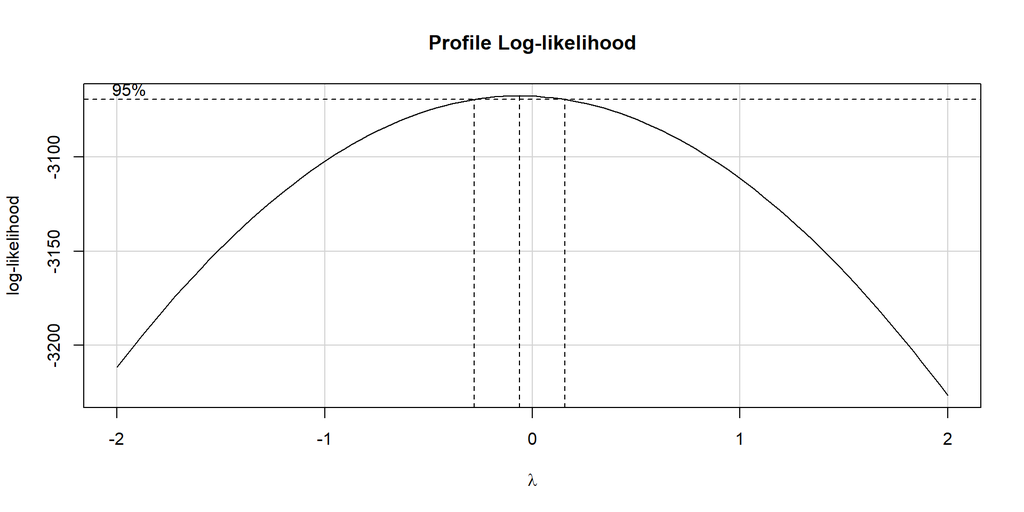

## Logarithm of LDL?

```r
p1 <- dm464 |>
  filter(stat_f == "Statin") |>
  ggplot(aes(sample = log(ldl))) +
  geom_qq() + geom_qq_line(col = "red") +
  labs(title = "Statin group", y = "log(LDL Cholesterol)",
        x = "Standard Normal")

p2 <- dm464 |>
  filter(stat_f == "No") |>
  ggplot(aes(sample = log(ldl))) +
  geom_qq() + geom_qq_line(col = "red") +
  labs(title = "No Statin group", y = "log(LDL Cholesterol)",
        x = "Standard Normal")

p1 + p2 +
  plot_annotation(title = "Normal Q-Q plots of log(LDL) by Statin group")
```

## Logarithm of LDL?

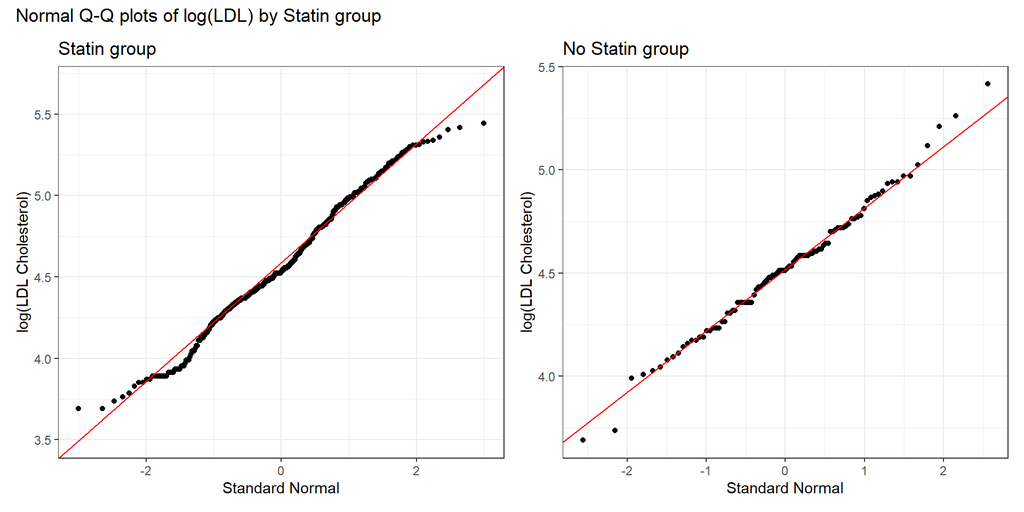

## Using the log transformation

```r
fit7 <- lm(log(ldl) ~ stat_f, data = dm464)
model_parameters(fit7, ci = 0.90)
```

```
Parameter       | Coefficient |   SE |        90% CI | t(462) |      p
----------------------------------------------------------------------
(Intercept)     |        4.52 | 0.04 | [ 4.46, 4.58] | 122.75 | < .001
stat f [Statin] |        0.05 | 0.04 | [-0.02, 0.12] |   1.23 | 0.220
```

```
Uncertainty intervals (equal-tailed) and p-values (two-tailed) computed
  using a Wald t-distribution approximation.
```

```
The model has a log-transformed response variable. Consider using
  `exponentiate = TRUE` to interpret coefficients as ratios.
```

- How do we interpret these results?
  - Should we exponentiate?

## Using the log transformation

```r
fit7 <- lm(log(ldl) ~ stat_f, data = dm464)
model_parameters(fit7, ci = 0.90)
```

```
Parameter       | Coefficient |   SE |        90% CI | t(462) |      p
----------------------------------------------------------------------
(Intercept)     |        4.52 | 0.04 | [ 4.46, 4.58] | 122.75 | < .001
stat f [Statin] |        0.05 | 0.04 | [-0.02, 0.12] |   1.23 | 0.220
```

- Subjects with statin prescriptions have, on average, 0.05 higher *log(LDL)* than subjects without a statin prescription.
- The 90% confidence interval for the Statin - No Statin difference in *log (LDL)* is (-0.02, 0.12).

## Exponentiating the Coefficients

```r
fit7 <- lm(log(ldl) ~ stat_f, data = dm464)
model_parameters(fit7, ci = 0.90, exponentiate = TRUE)
```

```
Parameter       | Coefficient |   SE |         90% CI | t(462) |      p
-----------------------------------------------------------------------
(Intercept)     |       91.67 | 3.37 | [86.27, 97.40] | 122.75 | < .001
stat f [Statin] |        1.05 | 0.04 | [ 0.98,  1.13] |   1.23 | 0.220
```

- After exponentiating, the point estimate for the comparison is 1.05, with 90% CI (0.98, 1.13).
- Subjects with statin prescriptions have, on average, 5% higher LDL than do subjects without such a prescription.
  - How should we interpret the confidence interval?

## Interpreting the Result Properly

- In our sample, subjects *with* a statin prescription have 5% higher LDL, on average, than do subjects *without*.
- When we generalize beyond these 464 subjects with diabetes to the population they were **selected at random** from, then our data are **compatible** (at the 90% confidence level) with population LDL values for statin users that are between 98% and 113% as large as non-statin users, depending on the **assumptions of our linear model** being correct after our log transformation of the outcome.

## Independent Samples Strategy (1)

Suppose we want to estimate an uncertainty interval for the difference in means across two groups. To begin, plot the data from each sample.

- If the sample data in each group are well described as “Normal”, then use the OLS / pooled t procedure to obtain a confidence interval, or a Bayesian model to obtain a credible interval.
  - If the sample sizes are not the same, and the sample variances aren’t close to each other, consider using a Welch t procedure.

## Independent Samples Strategy (2)

- If either sample’s data are “symmetric but with outliers”, then consider using the bootstrap to obtain a confidence interval, although an OLS or Bayesian result may also be reasonable.
- If either sample’s data are best described as “substantially skewed”, then consider whether you actually want to summarize with the difference in means, and consider whether a transformation might be helpful.